# Hypothesis Testing and Regression

Siegfred Codia

Stat 125, Second Semester, A.Y. 2022-2023

# **Introduction**

In this discussion, we will show some of the basic statistical tools and parametric tests:

- T test for difference of mean for two groups
- ANOVA test for difference of means of multiple groups
- Chi-Square test for independence
- Simple Linear Regression

Other tests will also be mentioned, since these are prerequisites to show that the dataset follows the assumptions of the mentioned statistical tests:

- Test for Normality (Shapiro-Wilk or Kolmogorov-Smirnov)
- Test for Homoscedasticity or Equality of Variance (Ftest, Levene’s test, Bartlett’s test, or Fligner-Killeen Test)

Plots will also be used to visualize data prior to testing

- Histogram to show shape of distribution
- Boxplot to show central tendency and dispersion
- Scatter plot to show correlation and (linear) relationship between two variables

These are just the basics and just the application in R. You should know beforehand how and when to use these statistical tests.

## Datasets

In the following examples, we will use the available data set from the `datasets` and `carData` libraries in R. The `datasets` package is loaded with base version of the RStudio and hence loading the library is not required. On the other hand `carData` is part of the `car` package and needs loading to R.

```r
# install.packages("car")
library(car)
```

## Functions to use

The `stats` package provide the functions for the hypothesis tests . Alternatively, `rstatix` also provide these, but outputs only the required values (statistic and p-value) and hence are more pipe-friendly.

```r
library(tidyverse)
library(rstatix)
```

# **Basic Hypothesis Tests**

## **T Test**

The **`mtcars`** dataset contains data on various aspects of 32 different automobile models, including their miles per gallon (mpg), number of cylinders, horsepower, and other factors.

Suppose we want to compare the consumption in miles per gallon (`mpg`) of cars with different numbers of cylinders = 4 and 6 using a t-test. Take note that the number of cylinders is converted to `factor`

```r
mtcars_sub <- subset(mtcars, cyl %in% c(4, 6))%>%
    select(mpg, cyl)%>%
    mutate(cyl = as.factor(cyl))
mtcars_sub
```

|  | mpg | cyl |
| --- | --- | --- |
| Mazda RX4 | 21.0 | 6 |
| Mazda RX4 Wag | 21.0 | 6 |
| Datsun 710 | 22.8 | 4 |
| Hornet 4 Drive | 21.4 | 6 |
| Valiant | 18.1 | 6 |
| Merc 240D | 24.4 | 4 |
| Merc 230 | 22.8 | 4 |
| Merc 280 | 19.2 | 6 |
| Merc 280C | 17.8 | 6 |
| Fiat 128 | 32.4 | 4 |

[output cut: 8 more lines]

```r
summary(mtcars_sub)
```

```
##       mpg        cyl
##  Min.   :17.80   4:11
##  1st Qu.:21.00   6: 7
##  Median :22.15
##  Mean   :23.97
##  3rd Qu.:26.98
##  Max.   :33.90
```

Let’s obtain the mean and standard deviation of `mpg` by `cyl`.

```r
summary_stat <- mtcars_sub%>%
    group_by(cyl)%>%
    summarize(mean(mpg),
              sd(mpg))
summary_stat
```

| cyl | mean(mpg) | sd(mpg) |
| --- | --- | --- |
| 4 | 26.66364 | 4.509828 |
| 6 | 19.74286 | 1.453567 |

### Visualization

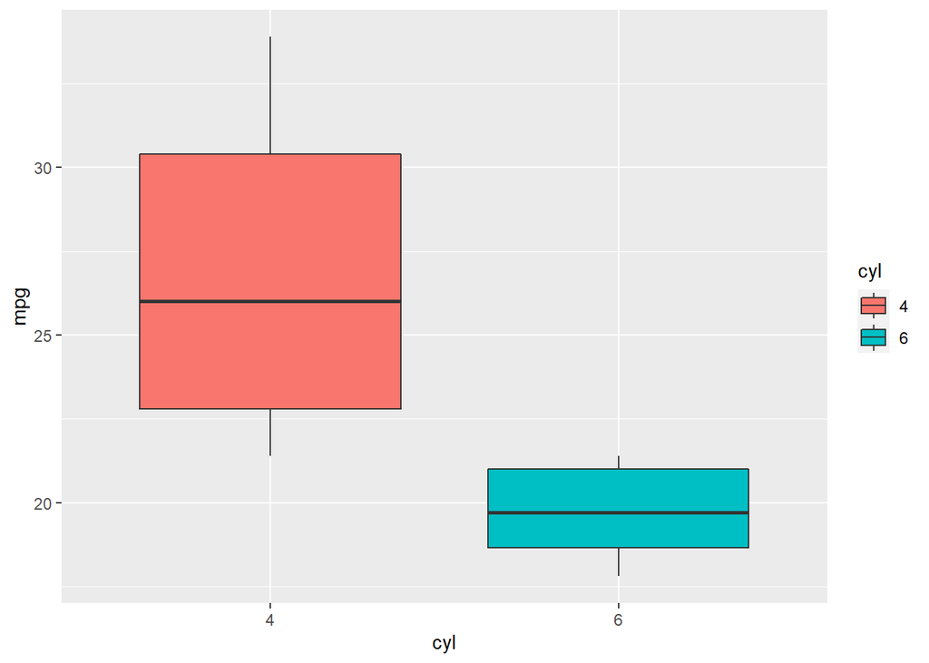

```r
mtcars_sub %>%
    ggplot(aes(x = cyl, fill = cyl, y = mpg))+
    geom_boxplot()
```

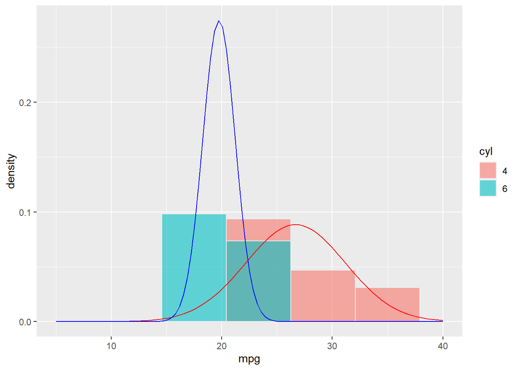

```r
mtcars_sub %>%
    ggplot(aes(x = mpg, fill = cyl))+xlim(5,40)+
    geom_histogram(color="#e9ecef", bins = 7, alpha = 0.6, position = "identity",
                   aes(y = ..density..))+
    stat_function(fun = dnorm,
                  args = list(mean = mean(filter(mtcars_sub, cyl == "4")$mpg),
                              sd = sd(filter(mtcars_sub, cyl == "4")$mpg)),
                  color = "red",
                  geom = "line")+
    stat_function(fun = dnorm,
                  args = list(mean = mean(filter(mtcars_sub, cyl == "6")$mpg),
                              sd = sd(filter(mtcars_sub, cyl == "6")$mpg)),
                  color = "blue",
                  geom = "line")
```

```r
library(ggridges)
```

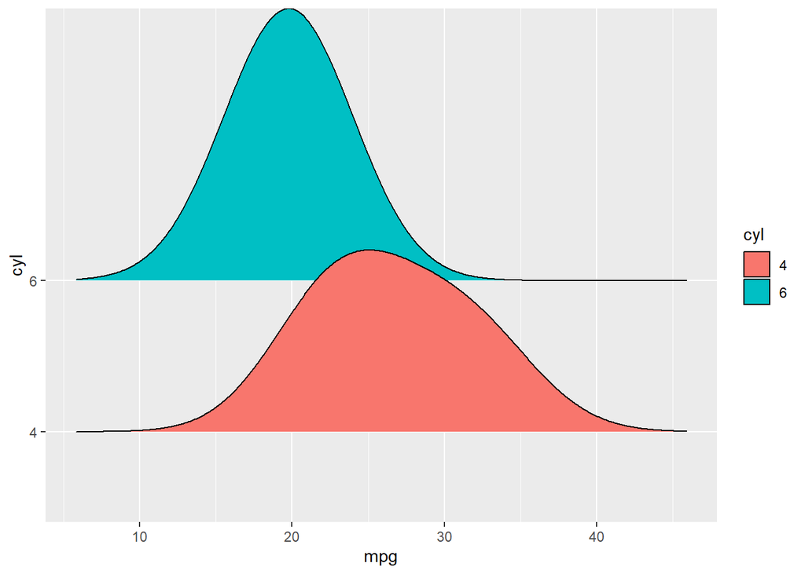

```r
mtcars_sub %>%
    ggplot(aes(x = mpg, fill = cyl, y = cyl))+
    geom_density_ridges(bandwidth = 4)
```

From the above visualizations, we can see the the average miles per gallon consumption is higher for vehicles with 4 cylinders than with 6 cylinders.

### Test for Normality

Shapiro-Wilk test for normality have a null assumption that your current data follows Normal distribution. Rejecting the null means that your data does not follow a normal distribution. To summarize:

$$Ho: \text{Data follows Normal Distribution}$$

$$Ha: \text{Data does not follow Normal Distribution}$$

The `shapiro.test` function of the `stats` library can help us test normality of a data stored in a vector.

```r
shapiro.test(mtcars_sub$mpg)
```

```
##
##  Shapiro-Wilk normality test
##
## data:  mtcars_sub$mpg
## W = 0.90193, p-value = 0.06209
```

However, the assumption of T test is that data from **EACH group is normal**, not when data is **aggregated**. Hence, results from the chunk above is not directly useful.

Let us use the `shapiro_test` of the `rstatix` package to test normality of the variable `mpg` grouped according to `cyl`.

```r
mtcars_sub %>% group_by(cyl) %>%
    summarize(shapiro_test(mpg))
```

| cyl | variable | statistic | p.value |
| --- | --- | --- | --- |
| 4 | mpg | 0.9124392 | 0.2605931 |
| 6 | mpg | 0.8990350 | 0.3251776 |

If the p-value for each group is >0.05, then data from each group follows normality.

*Note: Just a warning on the use of normality tests, when sample size is low, it is very likely that the null assumption of normality will not be rejected. For such cases, just use logic and context to reason that the generation of your data is a Gaussian (normal) process.*

### Test for Homoscedasticity

The `var.test` performs an F test to compare variances of two samples from normal population.

```r
var.test(mpg ~ cyl, mtcars_sub,
         alternative = "two.sided")
```

```
##
##  F test to compare two variances
##
## data:  mpg by cyl
## F = 9.6261, num df = 10, denom df = 6, p-value = 0.01182
## alternative hypothesis: true ratio of variances is not equal to 1
## 95 percent confidence interval:
##   1.762592 39.198688
## sample estimates:
## ratio of variances
##           9.626086
```

### Performing the T test

Let’s perform a two-tailed t-test assuming unequal variance.

```r
t.test(mpg ~ cyl, data = mtcars_sub, var.equal = F)
```

```
##
##  Welch Two Sample t-test
##
## data:  mpg by cyl
## t = 4.7191, df = 12.956, p-value = 0.0004048
## alternative hypothesis: true difference in means between group 4 and group 6 is not equal to 0
## 95 percent confidence interval:
##   3.751376 10.090182
## sample estimates:
## mean in group 4 mean in group 6
##        26.66364        19.74286
```

If we want to perform a one-tailed test (with direction of inequality), it is important that you know which is on the left hand side (LHS) and right hand side (RHS) of the inequality (unlike if the alternative is just $\neq$ ). To know which is on the LHS or RHS, check the order of levels. This works even if the factor variable is unordered.

```r
levels(mtcars_sub$cyl)
```

```
## [1] "4" "6"
```

For this case, the first argument in the inequality is the group with 4 cylinders. That is:

- `alternative = "two.sided"`: mpg with 4 cylinders $\neq$ mpg with 6 cylinders
- `alternative = "less"` : mpg with 4 cylinders $<$ mpg with 6 cylinders
- `alternative = "greater"` : mpg with 4 cylinders $>$ mpg with 6 cylinders

### Exercise: Try T test!

Using the same data, perform one sided t-test with `alternative = "less"` and `alternative = "greater"`

```r
# alternative = "less"
```

```r
# alternative = "greater"
```

What can you conclude about the consumption in `mpg` of cars with 4 cylinders vs cars with 6 cylinders?

## **ANOVA**

For the `PlantGrowth` dataset, we want to know if there are differences in weight of the plants under different treatment conditions.

```r
PlantGrowth
```

| weight | group |
| --- | --- |
| 4.17 | ctrl |
| 5.58 | ctrl |
| 5.18 | ctrl |
| 6.11 | ctrl |
| 4.50 | ctrl |
| 4.61 | ctrl |
| 5.17 | ctrl |
| 4.53 | ctrl |
| 5.33 | ctrl |
| 5.14 | ctrl |

[output cut: 20 more lines]

```r
summary(PlantGrowth)
```

```
##      weight       group
##  Min.   :3.590   ctrl:10
##  1st Qu.:4.550   trt1:10
##  Median :5.155   trt2:10
##  Mean   :5.073
##  3rd Qu.:5.530
##  Max.   :6.310
```

```r
PlantGrowth %>% group_by(group) %>%
    summarize(mean(weight), sd(weight))
```

| group | mean(weight) | sd(weight) |
| --- | --- | --- |
| ctrl | 5.032 | 0.5830914 |
| trt1 | 4.661 | 0.7936757 |
| trt2 | 5.526 | 0.4425733 |

### Visualization

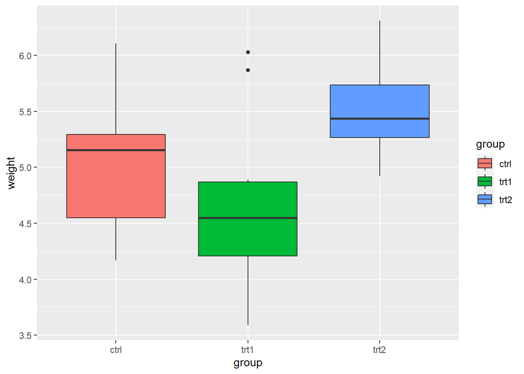

```r
PlantGrowth %>%
    ggplot(aes(x = group, fill = group, y = weight))+
    geom_boxplot()
```

### Test for Normality

```r
library(rstatix)
PlantGrowth %>% group_by(group) %>%
    summarize(shapiro_test(weight))
```

| group | variable | statistic | p.value |
| --- | --- | --- | --- |
| ctrl | weight | 0.9566815 | 0.7474734 |
| trt1 | weight | 0.9304107 | 0.4519440 |
| trt2 | weight | 0.9410052 | 0.5642519 |

### Levene’s Test for Homoscedasticity

If the number of groups is greater than 2, we use Levene’s test instead of F test. We may only use this test for equality of variance if the samples are from normally distributed populations. **Null hypothesis** for this test is that the **variances are equal**.

```r
library(car)
leveneTest(weight ~ group, PlantGrowth)
```

|  | Df | F value | Pr(>F) |
| --- | --- | --- | --- |
| group | 2 | 1.119186 | 0.3412266 |
|  | 27 | NA | NA |

### Performing the ANOVA

Finally, we perform the anova using the `aov` function and the results can be shown by the `summary` function.

```r
anova1 <- aov(weight ~ group, PlantGrowth)
summary(anova1)
```

```
##             Df Sum Sq Mean Sq F value Pr(>F)
## group        2  3.766  1.8832   4.846 0.0159 *
## Residuals   27 10.492  0.3886
## ---
## Signif. codes:  0 '***' 0.001 '**' 0.01 '*' 0.05 '.' 0.1 ' ' 1
```

### Post-hoc test

A significant one-way ANOVA is generally followed up by **post-hoc tests** to perform multiple pairwise comparisons between groups. One method is **Tukey’s Honestly Significant Difference** Test.

```r
TukeyHSD(anova1)
```

```
##   Tukey multiple comparisons of means
##     95% family-wise confidence level
##
## Fit: aov(formula = weight ~ group, data = PlantGrowth)
##
## $group
##             diff        lwr       upr     p adj
## trt1-ctrl -0.371 -1.0622161 0.3202161 0.3908711
## trt2-ctrl  0.494 -0.1972161 1.1852161 0.1979960
## trt2-trt1  0.865  0.1737839 1.5562161 0.0120064
```

Other common post-hoc tests are Bonferroni, Scheffe, and Tukey-Kramer, each has different assumption on distribution and sample sizes. In Stat 148, you will know which test is appropriate based on your data to balance power and robustness of the test.

## $\chi^2$ **test for Independence**

The `TitanicSurvival` dataset in the library `carData` provides information on the passengers of the Titanic, including whether they survived or not, their class, age, and sex.

```r
library(carData)
TitanicSurvival
```

|  | survived | sex | age | passengerClass |
| --- | --- | --- | --- | --- |
| Allen, Miss. Elisabeth Walton | yes | female | 29.0000 | 1st |
| Allison, Master. Hudson Trevor | yes | male | 0.9167 | 1st |
| Allison, Miss. Helen Loraine | no | female | 2.0000 | 1st |
| Allison, Mr. Hudson Joshua Crei | no | male | 30.0000 | 1st |
| Allison, Mrs. Hudson J C (Bessi | no | female | 25.0000 | 1st |
| Anderson, Mr. Harry | yes | male | 48.0000 | 1st |
| Andrews, Miss. Kornelia Theodos | yes | female | 63.0000 | 1st |
| Andrews, Mr. Thomas Jr | no | male | 39.0000 | 1st |
| Appleton, Mrs. Edward Dale (Cha | yes | female | 53.0000 | 1st |
| Artagaveytia, Mr. Ramon | no | male | 71.0000 | 1st |

[output cut: 1299 more lines]

Recall the null hypothesis of a Chi-square test for independence:

$$Ho: \text{No association between the two categorical variables}$$

Suppose we want to know if the survival of an individual is dependent on their sex.

```r
tab <- table(TitanicSurvival$survived, TitanicSurvival$sex)
tab
```

```
##
##       female male
##   no     127  682
##   yes    339  161
```

### Visualization

A mosaic plot is a proportional display for a n-way table.

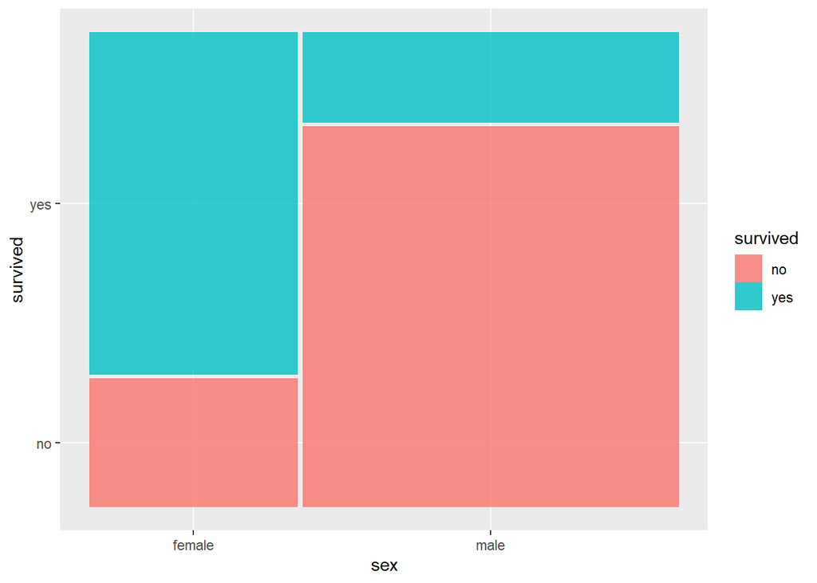

```r
library(ggmosaic)
ggplot(TitanicSurvival) +
  geom_mosaic(aes(x = product(sex), fill = survived))
```

### Peforming Chi-square test for independence

Let us perform a Chi-square test using the `chisq.test` of the `stats` package.

The output of the chi-squared test will include the chi-squared statistic, degrees of freedom, and the p-value. If the p-value is less than the significance level (usually 0.05), we can reject the null hypothesis that the two variables are independent.

Note that if the contingency table is **2x2**, **Yate’s continuity** correction is enabled by default. You can disable this by setting `correct = F`.

```r
chisq.test(TitanicSurvival$survived, TitanicSurvival$sex)
```

```
##
##  Pearson's Chi-squared test with Yates' continuity correction
##
## data:  TitanicSurvival$survived and TitanicSurvival$sex
## X-squared = 363.62, df = 1, p-value < 2.2e-16
```

What is the conclusion?

### Exercise: Try Chi-square

Now, test whether the survival rate of passengers was independent of their class using the `survived` and `passengerClass` variables.

```r
# mosaic plot here
```

```r
## chi square test  here
```

# **Linear Regression**

Data by Anscombe, F.J. (1981) which contains the following columns:

- `education` per-capita expenditure, dollars
- `income` per-capita income, dollars
- `young` proportion under 18, per 1000
- `urban` proportion urban, per 1000

```r
Anscombe
```

|  | education | income | young | urban |
| --- | --- | --- | --- | --- |
| ME | 189 | 2824 | 350.7 | 508 |
| NH | 169 | 3259 | 345.9 | 564 |
| VT | 230 | 3072 | 348.5 | 322 |
| MA | 168 | 3835 | 335.3 | 846 |
| RI | 180 | 3549 | 327.1 | 871 |
| CT | 193 | 4256 | 341.0 | 774 |
| NY | 261 | 4151 | 326.2 | 856 |
| NJ | 214 | 3954 | 333.5 | 889 |
| PA | 201 | 3419 | 326.2 | 715 |
| OH | 172 | 3509 | 354.5 | 753 |

[output cut: 41 more lines]

```r
summary(Anscombe)
```

```
##    education         income         young           urban
##  Min.   :112.0   Min.   :2081   Min.   :326.2   Min.   : 322.0
##  1st Qu.:165.0   1st Qu.:2786   1st Qu.:342.1   1st Qu.: 552.5
##  Median :192.0   Median :3257   Median :354.1   Median : 664.0
##  Mean   :196.3   Mean   :3225   Mean   :358.9   Mean   : 664.5
##  3rd Qu.:228.5   3rd Qu.:3612   3rd Qu.:369.1   3rd Qu.: 790.5
##  Max.   :372.0   Max.   :4425   Max.   :439.7   Max.   :1000.0
```

Let us first explore the correlation matrix. The following correlation matrix shows pairwise correlation of each variable.

```r
cor(Anscombe)
```

```
##           education     income      young      urban
## education 1.0000000  0.6675773  0.3114855  0.2633238
## income    0.6675773  1.0000000 -0.1623600  0.6854580
## young     0.3114855 -0.1623600  1.0000000 -0.1386334
## urban     0.2633238  0.6854580 -0.1386334  1.0000000
```

## Simple Linear Regression Models

Suppose we want to find the linear relationship of budget on education and income per capita of the states.

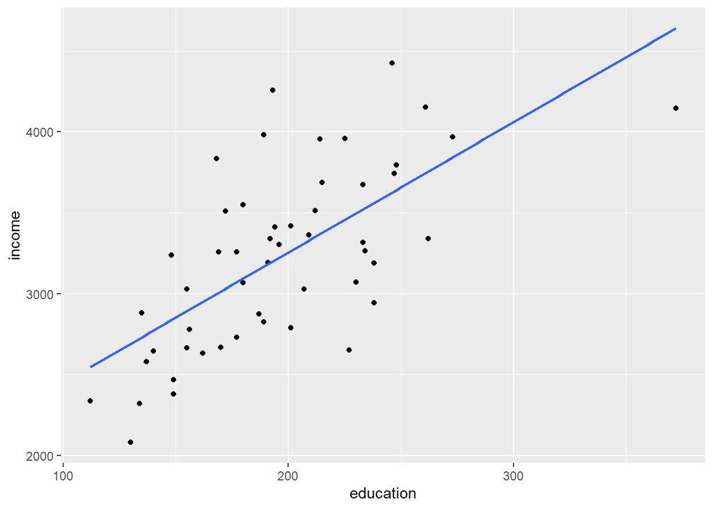

```r
ggplot(Anscombe, aes(x = education, y = income))+
    geom_point()+
    geom_smooth(method = "lm", se = F)
```

The correlation of income and education is 0.66, which shows a moderate to strong positive correlation. The plot above visualizes this relationship. Let us perform a linear regression to quantify the relationship.

```r
mod1 <- lm(income ~ education, data = Anscombe)
mod1
```

```
##
## Call:
## lm(formula = income ~ education, data = Anscombe)
##
## Coefficients:
## (Intercept)    education
##    1645.383        8.048
```

```r
summary(mod1)
```

```
##
## Call:
## lm(formula = income ~ education, data = Anscombe)
##
## Residuals:
##     Min      1Q  Median      3Q     Max
## -821.25 -341.15    8.47  196.23 1057.37
##
## Coefficients:
##             Estimate Std. Error t value Pr(>|t|)
## (Intercept) 1645.383    258.539   6.364 6.41e-08 ***
## education      8.048      1.282   6.276 8.76e-08 ***
## ---
## Signif. codes:  0 '***' 0.001 '**' 0.01 '*' 0.05 '.' 0.1 ' ' 1
##
## Residual standard error: 421.2 on 49 degrees of freedom
## Multiple R-squared:  0.4457, Adjusted R-squared:  0.4343
## F-statistic: 39.39 on 1 and 49 DF,  p-value: 8.762e-08
```

### Try Simple Linear Regression

The urban ratio have positive correlation with the income per capita.

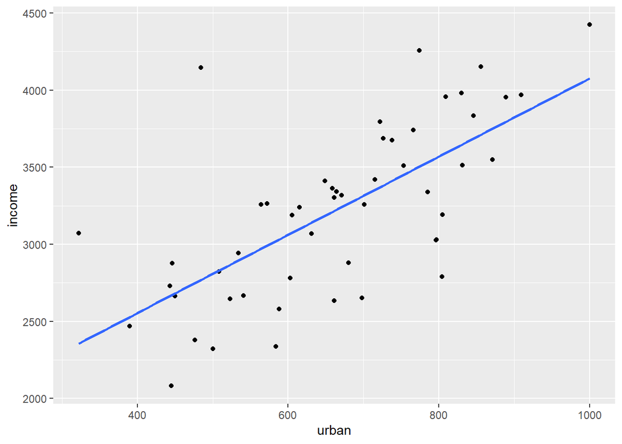

```r
ggplot(Anscombe, aes(y = income, x = urban))+
    geom_point()+
    geom_smooth(method = "lm", se = F)
```

Perform a linear regression with `income` as the dependent variable and `urban` ratio as the independent. Store the model on object `mod2` and view results using the `summary` function.

```r
### input answer here
mod2 <- lm(income ~ urban, data = Anscombe)
summary(mod2)
```

```
##
## Call:
## lm(formula = income ~ urban, data = Anscombe)
##
## Residuals:
##     Min      1Q  Median      3Q     Max
## -789.10 -266.15   65.64  242.66 1378.55
##
## Coefficients:
##              Estimate Std. Error t value Pr(>|t|)
## (Intercept) 1539.8170   262.1885   5.873 3.67e-07 ***
## urban          2.5364     0.3849   6.590 2.87e-08 ***
## ---
## Signif. codes:  0 '***' 0.001 '**' 0.01 '*' 0.05 '.' 0.1 ' ' 1
##
## Residual standard error: 411.9 on 49 degrees of freedom
## Multiple R-squared:  0.4699, Adjusted R-squared:  0.459
## F-statistic: 43.43 on 1 and 49 DF,  p-value: 2.866e-08
```

## Multiple Linear Regression

We have shown that `urban` ratio and budget for `education` both have linear relationship with `income` per capita. However, the models (with only 1 independent variable each) are not sufficient enough to explain the variation of `income`, shown in the values of R^2.

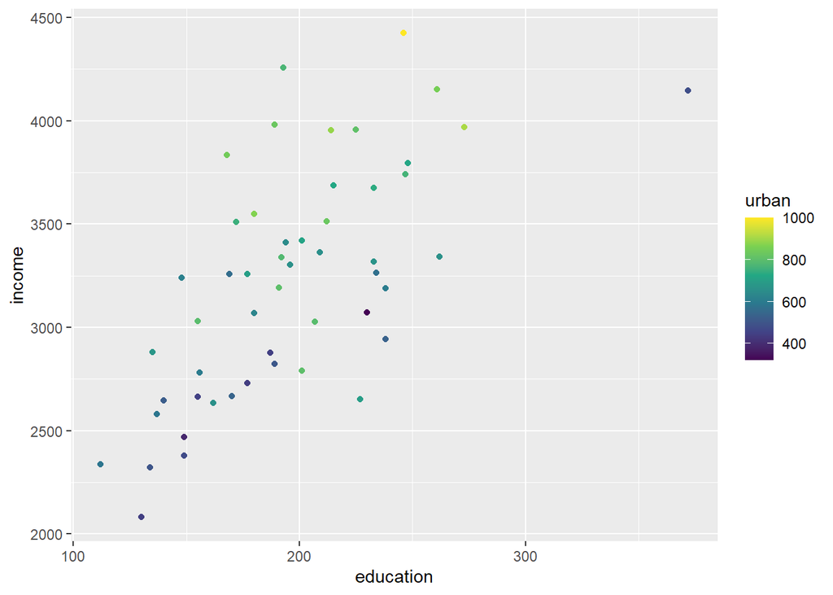

```r
ggplot(Anscombe, aes(y = income, x = education, color = urban))+
    geom_point()+
    scale_color_viridis_c() # viridis is a color palette
```

We not fit the following line on the data:

$$Y_{income} = \beta_0 +\beta_1 X_{education} + \beta_2 X_{urban}
+\varepsilon$$

```r
mod3 <- lm(income ~ education + urban, data = Anscombe)
summary(mod3)
```

```
##
## Call:
## lm(formula = income ~ education + urban, data = Anscombe)
##
## Residuals:
##     Min      1Q  Median      3Q     Max
## -835.77 -170.76   13.54  157.23  829.74
##
## Coefficients:
##             Estimate Std. Error t value Pr(>|t|)
## (Intercept) 640.0676   233.7516   2.738  0.00864 **
## education     6.3094     0.9463   6.668 2.38e-08 ***
## urban         2.0265     0.2904   6.977 7.97e-09 ***
## ---
## Signif. codes:  0 '***' 0.001 '**' 0.01 '*' 0.05 '.' 0.1 ' ' 1
##
## Residual standard error: 299.9 on 48 degrees of freedom
## Multiple R-squared:  0.7248, Adjusted R-squared:  0.7133
## F-statistic:  63.2 on 2 and 48 DF,  p-value: 3.568e-14
```

Notice how the value of $R^2$ increased.

### Prediction

Using the original data, we obtain the fitted values of `income` from the model (`mod3`) with education and urban as predictors. We use the `predict` function to predict value of the dependent variable y given the values of the regressors. `resid` is the difference between the observed values and the fitted values.

```r
fitted3 <- predict(mod3, Anscombe)
resid3 <- resid(mod3)
data.frame(Anscombe$income, fitted3,resid3)
```

|  | Anscombe.income | fitted3 | resid3 |
| --- | --- | --- | --- |
| ME | 2824 | 2861.988 | -37.988284 |
| NH | 3259 | 2849.282 | 409.718477 |
| VT | 3072 | 2743.753 | 328.246634 |
| MA | 3835 | 3414.433 | 420.566867 |
| RI | 3549 | 3540.808 | 8.192398 |
| CT | 4256 | 3426.264 | 829.736331 |
| NY | 4151 | 4021.474 | 129.526307 |
| NJ | 3954 | 3791.804 | 162.195910 |
| PA | 3419 | 3357.178 | 61.821973 |
| OH | 3509 | 3251.210 | 257.789742 |

[output cut: 41 more lines]

In terms of notation, a fitted value is denoted as $\hat{y}_i$ where $i$ is a specific observation (state).

Now, suppose we want to predict the income of 2 new states, and data for `education`, `young` ratio, and `urban` ratio are available. Data is stored in dataframe `new_states`.

```r
new_state1 <- c(education = 190, young = 350, urban = 500)
new_state2 <- c(education = 300, young = 275, urban = 250)
new_states <- data.frame(rbind(new_state1, new_state2))
new_states
```

|  | education | young | urban |
| --- | --- | --- | --- |
| new_state1 | 190 | 350 | 500 |
| new_state2 | 300 | 275 | 250 |

Note that the new data frame `new_states` has the same columns required for the predictors stored in the lm object `mod3` (which are `education` and `urban`). We can predict the expected income of the two new states given the predictors.

```r
predict(mod3, new_states)
```

```
## new_state1 new_state2
##   2852.086   3039.508
```

### Try Multiple Linear Regression

Add another predictor, which is the ratio of the young population.

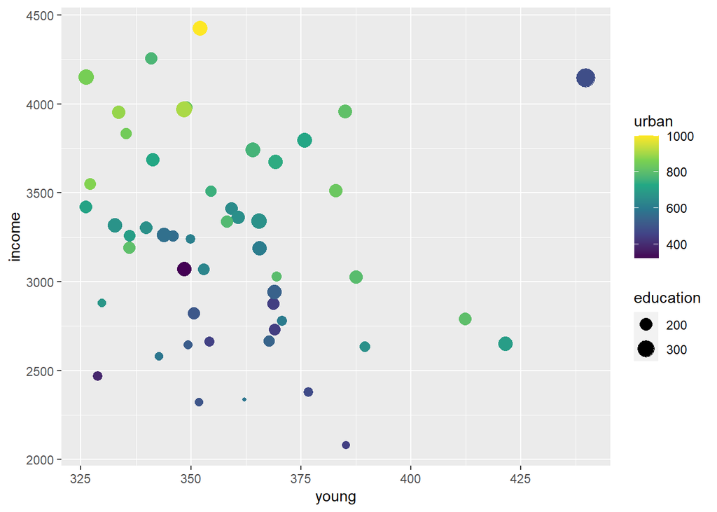

```r
ggplot(Anscombe, aes( y = income, x = young, color = urban, size = education))+
    geom_point()+
    scale_color_viridis_c()
```

Fit the following model:

$$Y_{income} = \beta_0 +\beta_1X_{education} + \beta_2X_{urban}
+\beta_3X_{young}+\varepsilon$$

Store the model on variable `mod4` and then use `summary` to show results

```r
## type answer here
```

Using the new model, predict the income of new_state1 and new_state2.

```r
## type answer here:
```